# TFM: Estudio de los datos del conjunto de entrenamiento

## Diego Sanz Alonso

En esta libreta se van a analizar las características a nivel de clase que nos proporciona SourceMeter para ver si es necesario eliminar alguna, binarizarlas, cambiar la escala de las mismas, etc.

### 1) Importar librerías y creación de funciones auxiliares

```python
import numpy as np
import pandas as pd
from sklearn.model_selection import train_test_split
from sklearn.model_selection import cross_val_score
from sklearn import neighbors, tree
from sklearn.ensemble import RandomForestClassifier
import pickle
from math import ceil

from sklearn.metrics import accuracy_score
from sklearn.metrics import precision_score
from sklearn.metrics import recall_score
from sklearn.metrics import f1_score
from sklearn.metrics import roc_auc_score

import matplotlib as mpl
import matplotlib.pyplot as plt

import seaborn as sns
sns.set(color_codes=True)
```

```python
# Configuracion para seaborn
%matplotlib inline
mpl.rcParams["figure.figsize"] = "8, 4"
import warnings
warnings.simplefilter("ignore")
```

### 2) Leer datos y crear conjunto de entrenamiento y test

```python
input_data = "datasets/dataframes/"

# Classes dataframe
classes_df = pd.read_csv(input_data + "classes.csv")

# Atts and label(binary -> False: no bugs, True: bugs)
classes_df_atts = classes_df.drop(["Number of bugs"], axis = 1)
classes_df_label = classes_df["Number of bugs"] > 0

print("Total de casos: ", len(classes_df))
print("Clases sin bugs (negativos): ",len(classes_df_label[~classes_df_label]))
print("Clases con bugs (positivos): ", len(classes_df_label[classes_df_label]))
print("Proporcion de clases con bugs: ", round(len(classes_df_label[classes_df_label])/len(classes_df_label)*100,2),'%')
```

```
Total de casos:  182671
Clases sin bugs (negativos):  174396
Clases con bugs (positivos):  8275
Proporcion de clases con bugs:  4.53 %
```

```python
atts = ""
for att in classes_df.columns:
    atts = atts + ", " + att
print("Lista completa de características")
atts[2:]
```

```
Lista completa de características
```

[output not shown]

```python
atts_before = set(classes_df.columns)
```

```python
print("Número de variables inicial: ", len(classes_df.columns) - 1)
```

```
Número de variables inicial:  106
```

### 1) Number of bugs

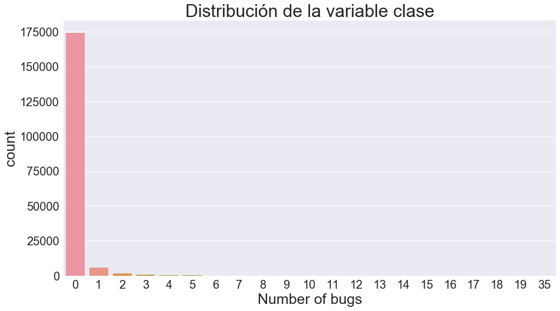

```python
fig, ax = plt.subplots()
fig.set_size_inches(15, 8)
#ax.set(yscale="log")
ax.set_xlabel('xlabel', fontsize=25)
ax.set_ylabel('ylabel', fontsize=25)
ax.tick_params(labelsize=20)
ax.set_title("Distribución de la variable clase", fontsize=30)
sns.countplot(data=classes_df, x="Number of bugs", ax=ax);
```

Se puede ver como la gran mayoría de las clases no tiene bugs, por lo que la variable clase la haremos binaria, de forma que indiquemos si tiene bugs o no, no la cantidad de bugs que tiene.

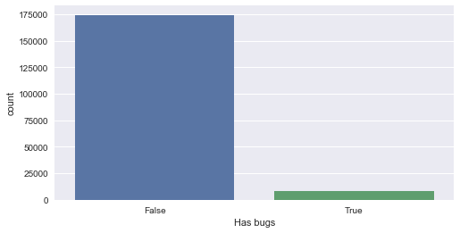

```python
classes_df["Has bugs"] = classes_df["Number of bugs"] > 0
classes_df = classes_df.drop(["Number of bugs"], 1)
sns.countplot(data = classes_df, x = "Has bugs");
```

### 2) Atributos Line, Column, EndLine y EndColumn

```python
classes_df[["Line", "Column", "EndLine", "EndColumn"]].describe()
```

|  | Line | Column | EndLine | EndColumn |
| --- | --- | --- | --- | --- |
| count | 182671.000000 | 182671.000000 | 182671.000000 | 182671.000000 |
| mean | 156.067975 | 15.655233 | 237.213104 | 5.180406 |
| std | 366.735787 | 31.875233 | 402.877656 | 6.033586 |
| min | 1.000000 | 1.000000 | 4.000000 | 2.000000 |
| 25% | 30.000000 | 1.000000 | 68.000000 | 2.000000 |
| 50% | 43.000000 | 1.000000 | 123.000000 | 2.000000 |
| 75% | 133.000000 | 5.000000 | 250.000000 | 6.000000 |
| max | 13502.000000 | 365.000000 | 13518.000000 | 191.000000 |

```python
classes_df.sample(n=10)[["Line", "Column", "EndLine", "EndColumn"]]
```

|  | Line | Column | EndLine | EndColumn |
| --- | --- | --- | --- | --- |
| 56438 | 34 | 1 | 88 | 2 |
| 89330 | 38 | 38 | 54 | 14 |
| 177696 | 46 | 65 | 51 | 10 |
| 136046 | 28 | 1 | 64 | 2 |
| 156256 | 148 | 61 | 162 | 25 |
| 34686 | 382 | 122 | 386 | 10 |
| 147017 | 27 | 1 | 51 | 2 |
| 39389 | 33 | 1 | 59 | 2 |
| 100627 | 33 | 1 | 140 | 2 |
| 17323 | 30 | 1 | 95 | 2 |

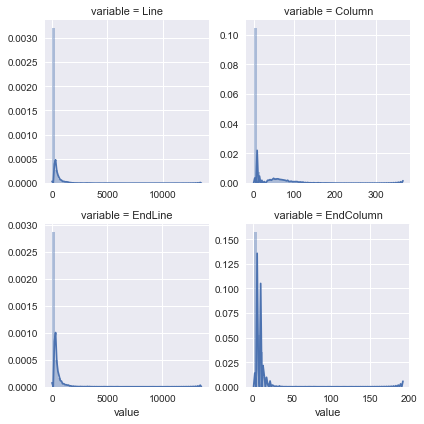

```python
# Histograma multiple
g = sns.FacetGrid(pd.melt(classes_df[["Line", "Column", "EndLine", "EndColumn"]]), col="variable", sharey=False, sharex=False, col_wrap=2)
g.map(sns.distplot, "value");
```

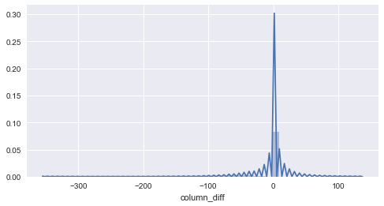

```python
classes_df["column_diff"] = classes_df["EndColumn"] - classes_df["Column"]
sns.distplot(classes_df["column_diff"]);
classes_df = classes_df.drop("column_diff", 1)
```

Vemos como para estas variables, que indican la posición de la clase dentro de cada archivo (imagino, en la documentación no lo especifica), suelen ser valores pequeños (ya que los archivos no suelen tener muchas líneas de código). En cuanto a las columnas, vemos como casi siempre la diferencia suele ser 1. No parece que las características Line y EndLine vayan a dar mucha información ya que hay otras variables que expresan mejor estas características.

### 3) Métricas relacionadas con código clonado

#### 3.1) CC

Esta variable marca la cobertura de clonado (*Clone coverage*), que indica el ratio de código duplicado en cada clase.

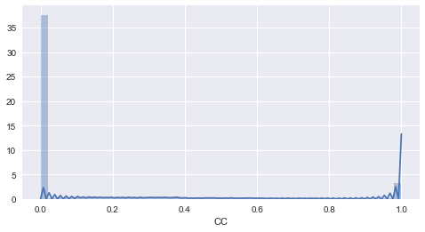

```python
sns.distplot(classes_df["CC"]);
```

```python
print("Clases sin código clonado: ", len(classes_df[(classes_df["CC"] == 0)]))
print("Clases con TODO el código clonado: ", len(classes_df[(classes_df["CC"] == 1)]))
print("Clases con algo de código clonado: ", len(classes_df[(classes_df["CC"] > 0) & (classes_df["CC"] < 1)]))
```

```
Clases sin código clonado:  137230
Clases con TODO el código clonado:  11493
Clases con algo de código clonado:  33948
```

Se puede ver que hay una gran cantidad de clases que no son clones de ninguna otra.

#### 3.2) CCL

Esta variable representa el número de clases clones que tiene cada una de las clases (según la doc de SourceMeter "number of clone classes having at least one clone instance in the source code element.")

```python
classes_df["CCL"].describe()
```

```
count    182671.000000
mean          0.911995
std           4.913028
min           0.000000
25%           0.000000
50%           0.000000
75%           0.000000
max         479.000000
Name: CCL, dtype: float64
```

```python
print("Valores mayores:", list(np.sort(classes_df["CCL"])[-10:]))
```

```
Valores mayores: [331, 332, 332, 332, 478, 478, 478, 479, 479, 479]
```

Se puede ver por los percentiles que el 75% de los valores son 0, por lo que las clases no suelen tener copias.

#### 3.3) CCO

Complejidad ciclomática del código duplicado.

```python
classes_df["CCO"].describe()
```

```
count    182671.000000
mean          5.101204
std          98.964455
min           0.000000
25%           0.000000
50%           0.000000
75%           0.000000
max       19402.000000
Name: CCO, dtype: float64
```

```python
classes_df[classes_df["CCO"]>0]["CCO"].describe()
```

```
count    45407.000000
mean        20.521990
std        197.699269
min          1.000000
25%          2.000000
50%          5.000000
75%         12.000000
max      19402.000000
Name: CCO, dtype: float64
```

```python
print("Valores mayores:", list(np.sort(classes_df["CCO"])[-10:]))
```

```
Valores mayores: [6319, 6319, 6319, 10040, 10040, 10040, 10041, 10041, 10041, 19402]
```

Se puede ver por los percentiles que el 75% o más de los valores son 0, y entre los restantes la mayoría tienen un valor pequeño (entre 1 y 12), y luego hay algunos casos excepcionales hasta llegar a los 19402 del valor máximo.

#### 3.4) CI

Número de instancias clone de la clase (según la doc de SourceMeter "number of clone instances in the source code element"). No sé en qué se diferencia de CCL pero los valores son distintos, aunque cuando uno es 0 el otro también.

```python
# Clases que tengan CI con valor 0 y CCL con otro valor y viceversa
len(classes_df[((classes_df["CI"] == 0) & (classes_df["CCL"] != 0) | (classes_df["CI"] != 0) & (classes_df["CCL"] == 0))])
```

```
0
```

```python
classes_df["CI"].describe()
```

```
count    182671.000000
mean          1.458644
std          16.737440
min           0.000000
25%           0.000000
50%           0.000000
75%           0.000000
max        2188.000000
Name: CI, dtype: float64
```

```python
classes_df[classes_df["CI"]>0]["CI"].describe()
```

```
count    45407.000000
mean         5.868082
std         33.183515
min          1.000000
25%          1.000000
50%          2.000000
75%          4.000000
max       2188.000000
Name: CI, dtype: float64
```

```python
print("Valores mayores:", list(np.sort(classes_df["CI"])[-10:]))
```

```
Valores mayores: [1138, 1138, 1138, 1523, 2187, 2187, 2187, 2188, 2188, 2188]
```

Se puede ver por los percentiles que el 75% o más de los valores son 0, y entre los restantes la mayoría tienen un valor pequeño (entre 1 y 4), y luego hay algunos casos excepcionales hasta llegar a los 2188 del valor máximo.

#### 3.5) CLC

Clone Line Coverage, igual que el CC pero expresado a niveld e líneas de código.

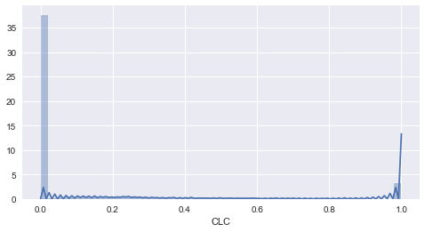

```python
sns.distplot(classes_df["CLC"]);
```

```python
print("Clases sin código clonado: ", len(classes_df[(classes_df["CLC"] == 0)]))
print("Clases con TODO el código clonado: ", len(classes_df[(classes_df["CLC"] == 1)]))
print("Clases con algo de código clonado: ", len(classes_df[(classes_df["CLC"] > 0) & (classes_df["CLC"] < 1)]))
```

```
Clases sin código clonado:  137203
Clases con TODO el código clonado:  11493
Clases con algo de código clonado:  33975
```

Tiene unos valores muy similares a CC.

```python
classes_df["CC"].corr(classes_df["CLC"])
```

```
0.9887326535999934
```

Se puede apreciar una correlación muy fuerte entre ellas.

#### 3.6) CLLC

Clone Logical Line Coverage, igual que CLC pero en términos de líneas lógicas.

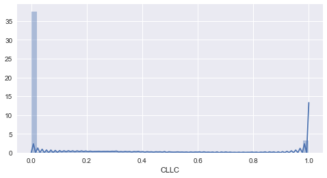

```python
sns.distplot(classes_df["CLLC"]);
```

```python
print("Clases sin código clonado: ", len(classes_df[(classes_df["CLLC"] == 0)]))
print("Clases con TODO el código clonado: ", len(classes_df[(classes_df["CLLC"] == 1)]))
print("Clases con algo de código clonado: ", len(classes_df[(classes_df["CLLC"] > 0) & (classes_df["CLC"] < 1)]))
```

```
Clases sin código clonado:  137203
Clases con TODO el código clonado:  11493
Clases con algo de código clonado:  33975
```

Tiene unos valores muy similares a CLC.

```python
classes_df["CLC"].corr(classes_df["CLLC"])
```

```
0.9968355087686628
```

Se puede apreciar una correlación muy fuerte entre ellas.

#### 3.7) LDC

Esta columna expresa las líneas de código duplicadas. En ella se puede ver como casi todos los valores son 0, como en el resto de casos, y que entre los valores que no son 0 hay algo más de diferencia en los valores, ya que ahora estamos viendo términos absolutos.

```python
classes_df["LDC"].describe()
```

```
count    182671.000000
mean         11.946198
std          99.178620
min           0.000000
25%           0.000000
50%           0.000000
75%           0.000000
max       12504.000000
Name: LDC, dtype: float64
```

```python
classes_df[classes_df["LDC"]>0]["LDC"].describe()
```

```
count    45468.000000
mean        47.994722
std        194.393734
min          1.000000
25%         11.000000
50%         20.000000
75%         40.000000
max      12504.000000
Name: LDC, dtype: float64
```

#### 3.8) LLDC

Esta columna expresa las líneas lógicas de código duplicadas. En ella se puede ver como casi todos los valores son 0, como en el resto de casos, y que entre los valores que no son 0 hay algo más de diferencia en los valores, ya que ahora estamos viendo términos absolutos.

```python
classes_df["LLDC"].describe()
```

```
count    182671.000000
mean         10.573731
std          84.477130
min           0.000000
25%           0.000000
50%           0.000000
75%           0.000000
max       10627.000000
Name: LLDC, dtype: float64
```

```python
classes_df[classes_df["LLDC"]>0]["LLDC"].describe()
```

```
count    45468.000000
mean        42.480734
std        165.275404
min          1.000000
25%         10.000000
50%         17.000000
75%         36.000000
max      10627.000000
Name: LLDC, dtype: float64
```

```python
classes_df["LLDC"].corr(classes_df["LDC"])
```

```
0.9982873536482735
```

#### Resumen características relacionadas con clones

```python
classes_df[["CC","CCL", "CCO", "CI", "CLC", "CLLC", "LDC", "LLDC"]].corr()
```

|  | CC | CCL | CCO | CI | CLC | CLLC | LDC | LLDC |
| --- | --- | --- | --- | --- | --- | --- | --- | --- |
| CC | 1.000000 | 0.300056 | 0.066408 | 0.142756 | 0.988733 | 0.994107 | 0.173474 | 0.177751 |
| CCL | 0.300056 | 1.000000 | 0.757366 | 0.878553 | 0.287792 | 0.299171 | 0.831812 | 0.832695 |
| CCO | 0.066408 | 0.757366 | 1.000000 | 0.845005 | 0.062153 | 0.067584 | 0.709092 | 0.714487 |
| CI | 0.142756 | 0.878553 | 0.845005 | 1.000000 | 0.138115 | 0.143090 | 0.925978 | 0.924259 |
| CLC | 0.988733 | 0.287792 | 0.062153 | 0.138115 | 1.000000 | 0.996836 | 0.161427 | 0.164766 |
| CLLC | 0.994107 | 0.299171 | 0.067584 | 0.143090 | 0.996836 | 1.000000 | 0.170454 | 0.174839 |
| LDC | 0.173474 | 0.831812 | 0.709092 | 0.925978 | 0.161427 | 0.170454 | 1.000000 | 0.998287 |
| LLDC | 0.177751 | 0.832695 | 0.714487 | 0.924259 | 0.164766 | 0.174839 | 0.998287 | 1.000000 |

Se puede ver que CC tiene una alta correlación con CLC y CLLC, y que LDC y LLDC también tienen un valor muy alto, por lo que sería conveniente eliminar algunas de estas columnas para eliminar ruido. También hay una correlación alta entre CCL, CCO y CI, aunque no es tan fuerte como los otros casos.

```python
classes_df = classes_df.drop(["CLC", "CLLC", "LLDC"], 1)
```

### 4) Métricas de cohesión

#### 4.1) LCOM5

*Lack of cohesion in Methods 5*, indica el número de funcionalidades de la clase. Medida calculada a partir de un grafo no dirigido.

```python
classes_df["LCOM5"].describe()
```

```
count    182671.000000
mean          1.613825
std           2.704235
min           0.000000
25%           1.000000
50%           1.000000
75%           2.000000
max         138.000000
Name: LCOM5, dtype: float64
```

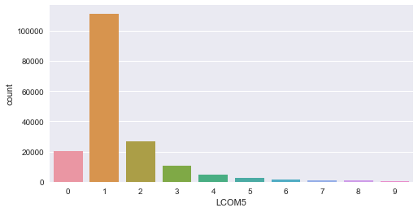

```python
sns.countplot(data = classes_df[classes_df["LCOM5"] < 10], x = "LCOM5");
```

Se puede ver como la mayoría de valores tienen el valor 1. Después una cantidad notable tienen el valor 0 y 2, y después el número va descendiendo paulatinamente a medida que crece el valor. Hay algunos valores más altos de lo habitual, llegando hasta los 138 del valor máximo.

### 5) Métricas de complejidad

#### 5.1) NL

*Nesting Level*, indica el grado de anidamiento máximo de cada clase.

```python
classes_df["NL"].describe()
```

```
count    182671.000000
mean          1.160622
std           2.005519
min           0.000000
25%           0.000000
50%           1.000000
75%           2.000000
max          80.000000
Name: NL, dtype: float64
```

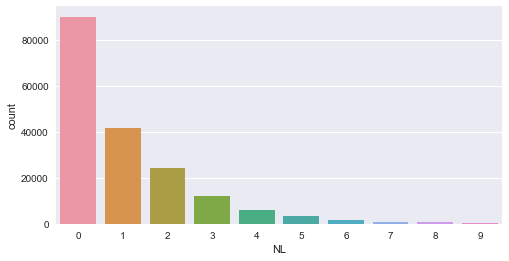

```python
sns.countplot(data = classes_df[classes_df["NL"] < 10], x = "NL");
```

En este caso la gran mayoría son 0 o valores muy bajos, aunque en algunos casos llega incluso a 80.

#### 5.2) NLE

*Nesting Level Else-if*, igual que NL pero los bloques if-else-if cuenta la primera instrucción.

```python
classes_df["NLE"].describe()
```

```
count    182671.000000
mean          1.012733
std           1.368315
min           0.000000
25%           0.000000
50%           1.000000
75%           2.000000
max          23.000000
Name: NLE, dtype: float64
```

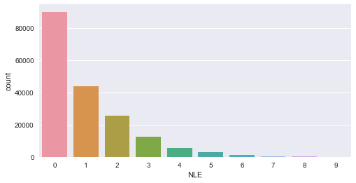

```python
sns.countplot(data = classes_df[classes_df["NLE"] < 10], x = "NLE");
```

```python
classes_df["NL"].corr(classes_df["NLE"])
```

```
0.8158867512155551
```

En este caso la gran mayoría son 0 o valores muy bajos, aunque en algunos casos llega incluso a 23. Está correlacionada con la anterior.

#### 5.3) WMC

*Weigthed Methods per Class*, número de caminos independientes de una clase. Se calcula como la suma de la complejidad ciclomática de los métodos locales y bloques de init.

```python
classes_df["WMC"].describe()
```

```
count    182671.000000
mean         11.413684
std          28.459880
min           0.000000
25%           2.000000
50%           4.000000
75%          11.000000
max        4474.000000
Name: WMC, dtype: float64
```

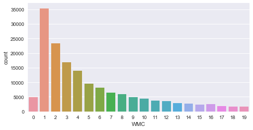

```python
sns.countplot(data = classes_df[classes_df["WMC"] < 20], x = "WMC");
```

Se puede ver como el número de casos va descendiendo a medida que aumenta el valor de esta variable, con la excepción del 0 que tiene un valor bastante menor que el 1. En algunos casos puede llegar a grandes números, como el 4474 del máximo.

### 6) Métricas de acoplamiento

#### 6.1) CBO

*Coupling between Object classes*, número de usos de otras clases. Clases con este valor muy alto serán muy dependientes de otros módulos, y por tanto más difíciles de testear y utilizar, además de muy sensibles a cambios.

```python
classes_df["CBO"].describe()
```

```
count    182671.000000
mean          5.983353
std           7.889404
min           0.000000
25%           2.000000
50%           4.000000
75%           7.000000
max         187.000000
Name: CBO, dtype: float64
```

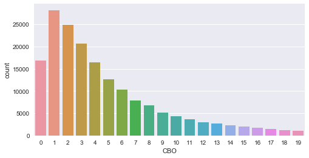

```python
sns.countplot(data = classes_df[classes_df["CBO"] < 20], x = "CBO");
```

#### 6.2) CBOI

*Coupling between Object classes Inverse*, número clases que utilizan esta clase. Clases con este valor muy alto tienen un gran impacto en el sistema, por lo que hay que tratarlas cuidadosamente.

```python
classes_df["CBOI"].describe()
```

```
count    182671.000000
mean          3.983199
std          17.151177
min           0.000000
25%           0.000000
50%           1.000000
75%           2.000000
max        1453.000000
Name: CBOI, dtype: float64
```

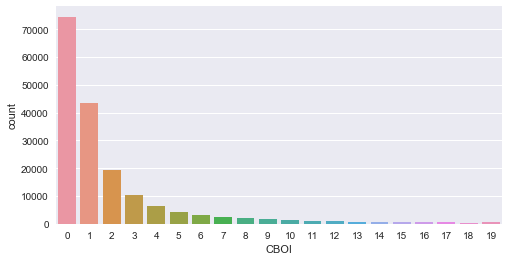

```python
sns.countplot(data = classes_df[classes_df["CBOI"] < 20], x = "CBOI");
```

El número de casos es menor a medida que incrementamos el valor. Al contrario que con la variable CBO, hay más casos con valor 0, lo que quiere decir que hay clases que no son utilizadas por ninguna otra.

#### 6.3) NII

*Number of Incoming Invocations*, número de métodos e inicialización de atributos que llaman a métodos locales de la clase.

```python
classes_df["NII"].describe()
```

```
count    182671.000000
mean          5.289652
std          34.461061
min           0.000000
25%           0.000000
50%           0.000000
75%           2.000000
max        2735.000000
Name: NII, dtype: float64
```

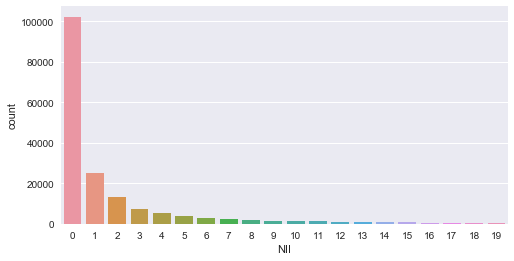

```python
sns.countplot(data = classes_df[classes_df["NII"] < 20], x = "NII");
```

Como en las otras métricas de acoplamiento, predominan valores bajos.

#### 6.4) NOI

*Number of Outgoing Invocations*, número de métodos e inicialización de atributos llamados de otras clases.

```python
classes_df["NOI"].describe()
```

```
count    182671.000000
mean          6.786310
std          13.531436
min           0.000000
25%           0.000000
50%           2.000000
75%           7.000000
max         381.000000
Name: NOI, dtype: float64
```

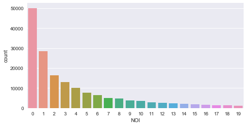

```python
sns.countplot(data = classes_df[classes_df["NOI"] < 20], x = "NOI");
```

Como en las otras métricas de acoplamiento, predominan valores bajos.

#### 6.5) RFC

*Response set For Class*, variable que construyen como NLM (*Number of Local Methods*) + NOI (*Number of Outgoing Methods*)

```python
classes_df["RFC"].describe()
```

```
count    182671.000000
mean         12.559191
std          20.169143
min           0.000000
25%           2.000000
50%           6.000000
75%          14.000000
max         847.000000
Name: RFC, dtype: float64
```

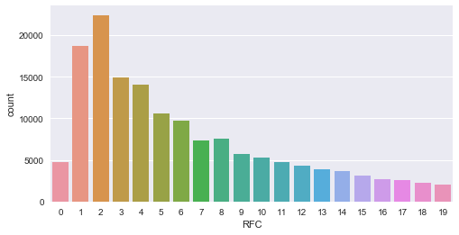

```python
sns.countplot(data = classes_df[classes_df["RFC"] < 20], x = "RFC");
```

En este caso vemos como el valor predominante es el 2, descenciendo el valor a medida que nos alejamos de él.

#### Comparación de correlación métricas de acoplamiento

```python
classes_df[["CBO","CBOI", "NII", "NOI", "RFC"]].corr()
```

|  | CBO | CBOI | NII | NOI | RFC |
| --- | --- | --- | --- | --- | --- |
| CBO | 1.000000 | 0.133385 | 0.153157 | 0.830632 | 0.759148 |
| CBOI | 0.133385 | 1.000000 | 0.774136 | 0.133740 | 0.231623 |
| NII | 0.153157 | 0.774136 | 1.000000 | 0.165981 | 0.266118 |
| NOI | 0.830632 | 0.133740 | 0.165981 | 1.000000 | 0.910171 |
| RFC | 0.759148 | 0.231623 | 0.266118 | 0.910171 | 1.000000 |

Vemos como la correlación más fuerte se encuentra entre NOI y RFC, lo cual tiene sentido si tenemos en cuenta que RFC se construye a partir de NOI y de otro atributo.

### 7) Métricas de documentación

#### 7.1) AD

*API Documentation*, ratio de métodos públicos documentados en la clase,

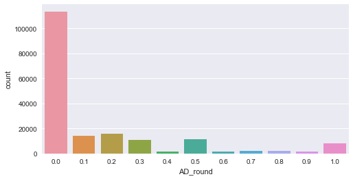

```python
classes_df["AD_round"] = classes_df["AD"].apply(lambda x: round(x,1))
sns.countplot(data = classes_df, x = "AD_round");
classes_df = classes_df.drop("AD_round", 1)
```

Se puede ver como la mayoría e clases no están comentadas.

#### 7.2) CD

*Comment Density*, ratio de líneas comentadas de código (CLOC) con respecto a la suma de CLOC y de las líneas lógicas de código (LLOC).

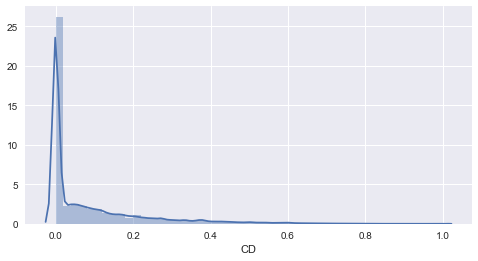

```python
sns.distplot(classes_df["CD"]);
```

```python
classes_df["AD"].corr(classes_df["CD"])
```

```
0.8166688093353043
```

#### 7.3) CLOC

*Comment Lines of Code*, número de líneas de código comentadas.

```python
classes_df["CLOC"].describe()
```

```
count    182671.000000
mean          8.465306
std          35.207994
min           0.000000
25%           0.000000
50%           1.000000
75%           5.000000
max        1573.000000
Name: CLOC, dtype: float64
```

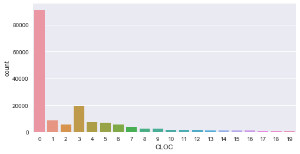

```python
sns.countplot(data = classes_df[classes_df["CLOC"] < 20], x = "CLOC");
```

Destaca que al margen de las clases sin comentar, haya más clases con 3 líneas comentadas que 1 ó 2.

#### 7.4) DLOC

*Documentation Lines of Code*, número de líneas de documentación.

```python
classes_df["DLOC"].describe()
```

```
count    182671.000000
mean          6.669915
std          30.981154
min           0.000000
25%           0.000000
50%           0.000000
75%           3.000000
max        1573.000000
Name: DLOC, dtype: float64
```

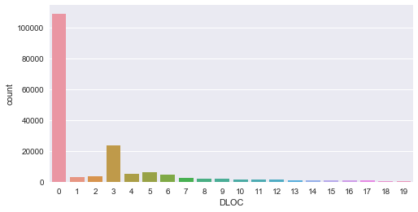

```python
sns.countplot(data = classes_df[classes_df["DLOC"] < 20], x = "DLOC");
```

```python
classes_df["CLOC"].corr(classes_df["DLOC"])
```

```
0.9536340893926952
```

Este atributo y el anterior están fuertemente correlacionados.

#### 7.5) PDA

*Public Documented API*, número de métodos públicos comentados en la clase.

```python
classes_df["PDA"].describe()
```

```
count    182671.000000
mean          1.048793
std           3.811576
min           0.000000
25%           0.000000
50%           0.000000
75%           1.000000
max         193.000000
Name: PDA, dtype: float64
```

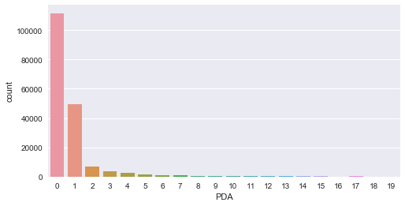

```python
sns.countplot(data = classes_df[classes_df["PDA"] < 20], x = "PDA");
```

En general las clases suelen tener uno o ningún comentario.

#### 7.6) PUA

*Public Undocumented API*, número de métodos públicos no comentados en la clase.

```python
classes_df["PUA"].describe()
```

```
count    182671.000000
mean          4.659492
std           7.326164
min           0.000000
25%           2.000000
50%           3.000000
75%           5.000000
max         203.000000
Name: PUA, dtype: float64
```

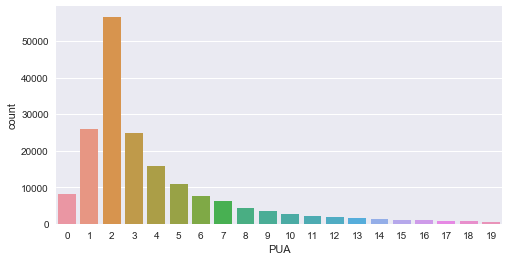

```python
sns.countplot(data = classes_df[classes_df["PUA"] < 20], x = "PUA");
```

#### 7.7) TCD

*Total comment Density*, ratio de líneas comentadas en la clase con respecto a la suma de ese valor y el número total de líneas lógicas de código.

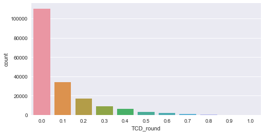

```python
classes_df["TCD_round"] = classes_df["TCD"].apply(lambda x: round(x,1))
sns.countplot(data = classes_df, x = "TCD_round");
classes_df = classes_df.drop("TCD_round", 1)
```

#### 7.8) TCLOC

*Total Comment Lines of Code*, líneas de código en la clase.

```python
classes_df["TCLOC"].describe()
```

```
count    182671.000000
mean          9.084162
std          38.851837
min           0.000000
25%           0.000000
50%           1.000000
75%           5.000000
max        1831.000000
Name: TCLOC, dtype: float64
```

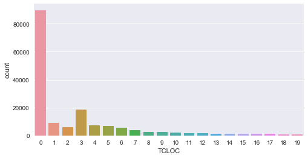

```python
sns.countplot(data = classes_df[classes_df["TCLOC"] < 20], x = "TCLOC");
```

#### Correlación de las métricas de documentación

```python
 classes_df[["AD", "CD", "CLOC", "DLOC", "PDA", "PUA", "TCD", "TCLOC"]].corr()
```

|  | AD | CD | CLOC | DLOC | PDA | PUA | TCD | TCLOC |
| --- | --- | --- | --- | --- | --- | --- | --- | --- |
| AD | 1.000000 | 0.816669 | 0.369780 | 0.398732 | 0.481327 | -0.165810 | 0.803721 | 0.357244 |
| CD | 0.816669 | 1.000000 | 0.407582 | 0.414201 | 0.411691 | -0.113732 | 0.985649 | 0.391529 |
| CLOC | 0.369780 | 0.407582 | 1.000000 | 0.953634 | 0.730212 | 0.091229 | 0.400687 | 0.982978 |
| DLOC | 0.398732 | 0.414201 | 0.953634 | 1.000000 | 0.786555 | 0.034692 | 0.407346 | 0.938852 |
| PDA | 0.481327 | 0.411691 | 0.730212 | 0.786555 | 1.000000 | 0.064108 | 0.408377 | 0.698136 |
| PUA | -0.165810 | -0.113732 | 0.091229 | 0.034692 | 0.064108 | 1.000000 | -0.110559 | 0.086700 |
| TCD | 0.803721 | 0.985649 | 0.400687 | 0.407346 | 0.408377 | -0.110559 | 1.000000 | 0.385054 |
| TCLOC | 0.357244 | 0.391529 | 0.982978 | 0.938852 | 0.698136 | 0.086700 | 0.385054 | 1.000000 |

Se puede ver como las variables CLOC (Líneas de código comentadas) y TCLOC (Total de líneas comentadas están muy correlacionadas, por lo que podemos eliminar una de ellas. Nos quedaremos con TCLOC porque es un caso más general (en la doc de SourceMeter indica que incluye líneas de código en clases locales y anónimas, lo que en el otro casos no.

Además, hay un índice de correlación entre CD y TCD de 0.9856, por lo que también podríamos eliminar 1.

Hay otras variables que mantienen cierta correlación, pero no es tan fuerte como en los casos mencionados antes, por lo que conservaremos todas las demás variables.

```python
classes_df = classes_df.drop(["CLOC", "TCD"], 1)
```

### 8) Métricas de herencia (inheritance)

#### 8.1) DIT

*Depth of inheritance tree*, tamaño del camino de la clase al ancestro más lejano en su árbol de herencia.

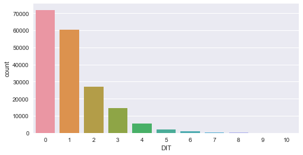

```python
sns.countplot(data = classes_df, x = "DIT");
```

Vemos que el valor suele ser bajo, llegando como mucho a 10.

#### 8.2) NOA

*Number of Ancestors*, número de clases, interfaces, enumeraciones y anotaciones que la clase hereda directa o indirectamente.

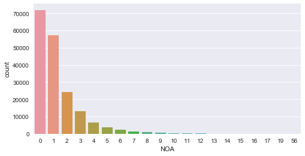

```python
sns.countplot(data = classes_df, x = "NOA");
```

Predominan valores bajos.

#### 8.3) NOC

*Number of Childrens*, número de clases, interfaces, enumeraciones y anotaciones que derivan de la clase directamente.

```python
classes_df["NOC"].describe()
```

```
count    182671.000000
mean          0.365986
std           3.316665
min           0.000000
25%           0.000000
50%           0.000000
75%           0.000000
max         318.000000
Name: NOC, dtype: float64
```

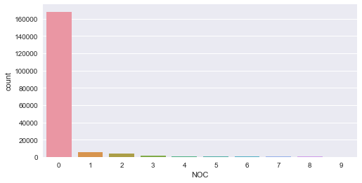

```python
sns.countplot(data = classes_df[classes_df["NOC"] < 10], x = "NOC");
```

```python
print("Casos distintos de 0:", len(classes_df[classes_df["NOC"] > 0]))
```

```
Casos distintos de 0: 14481
```

Casi todos los valores son 0.

#### 8.4) NOD

*Number of Descendant*, número de clases, interfaces, enumeraciones y anotaciones que derivan de la clase directa o indirectamente.

```python
classes_df["NOD"].describe()
```

```
count    182671.000000
mean          0.620799
std           7.481181
min           0.000000
25%           0.000000
50%           0.000000
75%           0.000000
max         811.000000
Name: NOD, dtype: float64
```

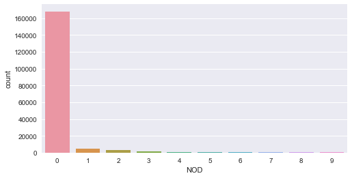

```python
sns.countplot(data = classes_df[classes_df["NOD"] < 10], x = "NOD");
```

```python
print("Casos distintos de 0:", len(classes_df[classes_df["NOD"] > 0]))
```

```
Casos distintos de 0: 14481
```

```python
classes_df["NOC"].corr(classes_df["NOD"])
```

```
0.7294551292164381
```

El valor también suele ser 0. Sin embargo, no tienen una correlación tan fuerte como podría parecer a priori.

#### 8.5) NOP

*Number of Parents*, número de clases, interfaces, enumeraciones y anotaciones de las que la clase deriva directamente.

```python
classes_df["NOP"].describe()
```

```
count    182671.000000
mean          0.673960
std           0.630434
min           0.000000
25%           0.000000
50%           1.000000
75%           1.000000
max          56.000000
Name: NOP, dtype: float64
```

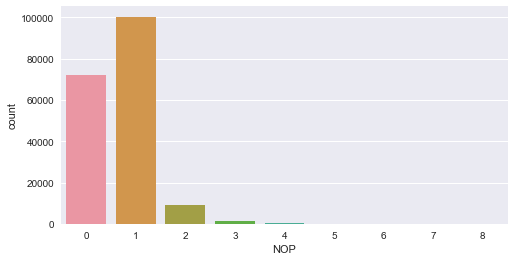

```python
sns.countplot(data = classes_df[classes_df["NOP"] < 10], x = "NOP");
```

En este caso vemos como hay bastantes más valores distintos de 0.

### 9) Métricas de tamaño

#### 9.1) LLOC

*Logical Lines of Code*, número de líneas lógicas de código.

```python
classes_df["LLOC"].describe()
```

```
count    182671.000000
mean         55.412375
std         135.243090
min           1.000000
25%          10.000000
50%          22.000000
75%          55.000000
max       11362.000000
Name: LLOC, dtype: float64
```

#### 9.2) LOC

*Lines of Code*, número de líneas de código.

```python
classes_df["LOC"].describe()
```

```
count    182671.000000
mean         71.945301
std         174.302778
min           1.000000
25%          12.000000
50%          28.000000
75%          70.000000
max       13460.000000
Name: LOC, dtype: float64
```

```python
classes_df["LLOC"].corr(classes_df["LOC"])
```

```
0.9842082245504903
```

Se aprecia una correlación bastante fuerte entre estas dos variables.

#### 9.3) NA

*Number of attributes*, número de atributos de la clase, incluyendo heredadas.

```python
classes_df["NA"].describe()
```

```
count    182671.000000
mean          4.696345
std           8.202217
min           0.000000
25%           0.000000
50%           2.000000
75%           5.000000
max         287.000000
Name: NA, dtype: float64
```

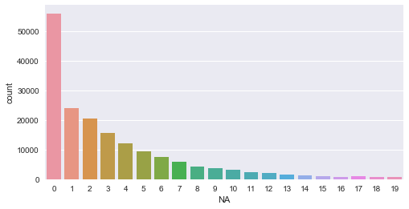

```python
sns.countplot(data = classes_df[classes_df["NA"] < 20], x = "NA");
```

La distribución sigue una tendencia descendente.

#### 9.4) NG

*Number of getters*, número de funciones get en la clase. Incluye heredadas.

```python
classes_df["NG"].describe()
```

```
count    182671.000000
mean          2.062544
std           5.059134
min           0.000000
25%           0.000000
50%           0.000000
75%           2.000000
max         224.000000
Name: NG, dtype: float64
```

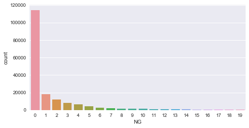

```python
sns.countplot(data = classes_df[classes_df["NG"] < 20], x = "NG");
```

En este caso el número de valores a 0 es mucho mayor,el resto de valores siguen una tendencia descendente.

#### 9.5) NLA

*Number of local attributes*, número de atributos locales de la clase.

```python
classes_df["NLA"].describe()
```

```
count    182671.000000
mean          2.074336
std           4.430673
min           0.000000
25%           0.000000
50%           1.000000
75%           3.000000
max         213.000000
Name: NLA, dtype: float64
```

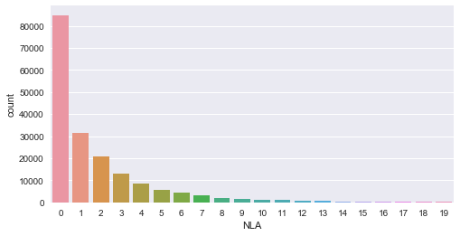

```python
sns.countplot(data = classes_df[classes_df["NLA"] < 20], x = "NLA");
```

La distribución sigue una tendencia descendente.

#### 9.6) NLG

*Number of local getters*, número de funciones get locales en la clase.

```python
classes_df["NLG"].describe()
```

```
count    182671.000000
mean          0.899858
std           2.971409
min           0.000000
25%           0.000000
50%           0.000000
75%           1.000000
max         224.000000
Name: NLG, dtype: float64
```

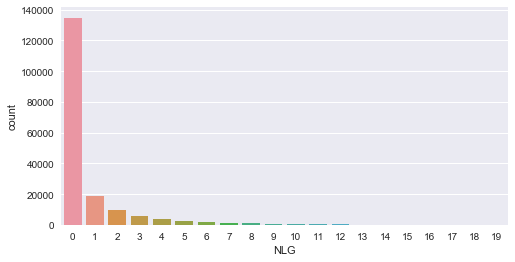

```python
sns.countplot(data = classes_df[classes_df["NLG"] < 20], x = "NLG");
```

En este caso el número de valores a 0 es mucho mayor,el resto de valores siguen una tendencia descendente.

#### 9.7) NLM

*Number of local methods*, número de métodos de la clase.

```python
classes_df["NLM"].describe()
```

```
count    182671.000000
mean          5.772881
std           9.648370
min           0.000000
25%           1.000000
50%           3.000000
75%           6.000000
max         715.000000
Name: NLM, dtype: float64
```

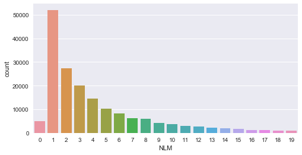

```python
sns.countplot(data = classes_df[classes_df["NLM"] < 20], x = "NLM");
```

Aquí no hay tantos valores con 0, y a partir del valro 1 sigue una tendencia descendente.

#### 9.8) NLPA

*Number of local public attributes*, número de atributos locales públicos de la clase.

```python
classes_df["NLPA"].describe()
```

```
count    182671.000000
mean          0.311226
std           2.529541
min           0.000000
25%           0.000000
50%           0.000000
75%           0.000000
max         211.000000
Name: NLPA, dtype: float64
```

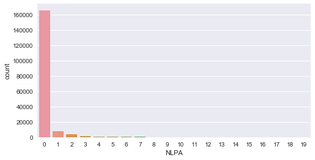

```python
sns.countplot(data = classes_df[classes_df["NLPA"] < 20], x = "NLPA");
```

En este caso vemos como más del 75% de las clases tienen 0 atributos públicos locales.

#### 9.9) NLPM

*Number of local public methods*, número de métodos locales de la clase.

```python
classes_df["NLPM"].describe()
```

```
count    182671.000000
mean          4.705832
std           8.471481
min           0.000000
25%           1.000000
50%           2.000000
75%           5.000000
max         225.000000
Name: NLPM, dtype: float64
```

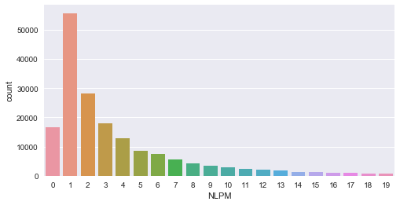

```python
sns.countplot(data = classes_df[classes_df["NLPM"] < 20], x = "NLPM");
```

#### 9.10) NLS

*Number of local setter*, número de métodos set locales de la clase.

```python
classes_df["NLS"].describe()
```

```
count    182671.000000
mean          0.359756
std           2.019450
min           0.000000
25%           0.000000
50%           0.000000
75%           0.000000
max          97.000000
Name: NLS, dtype: float64
```

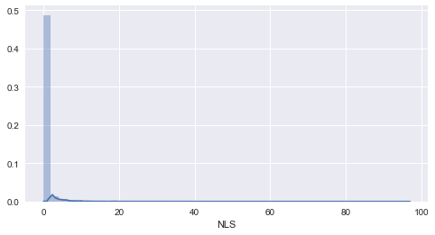

```python
sns.distplot(classes_df["NLS"]);
```

Casi todas las clases no tienen funciones set locales.

#### 9.11) NM

*Number of methods*, número de métodos de la clase.

```python
classes_df["NM"].describe()
```

```
count    182671.000000
mean         13.266725
std          22.430704
min           0.000000
25%           2.000000
50%           5.000000
75%          15.000000
max         715.000000
Name: NM, dtype: float64
```

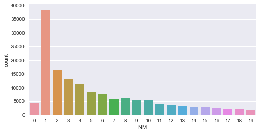

```python
sns.countplot(data = classes_df[classes_df["NM"] < 20], x = "NM");
```

#### 9.12) NOS

*Number of statements*, número de declaraciones en la clase.

```python
classes_df["NOS"].describe()
```

```
count    182671.000000
mean         28.068867
std          96.065919
min           0.000000
25%           2.000000
50%           8.000000
75%          25.000000
max        9509.000000
Name: NOS, dtype: float64
```

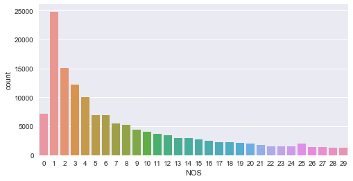

```python
sns.countplot(data = classes_df[classes_df["NOS"] < 30], x = "NOS");
```

#### 9.13) NPA

*Number of public attributes*, número de atributos públicos en la clase.

```python
classes_df["NPA"].describe()
```

```
count    182671.000000
mean          1.195203
std           4.889841
min           0.000000
25%           0.000000
50%           0.000000
75%           0.000000
max         265.000000
Name: NPA, dtype: float64
```

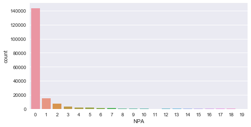

```python
sns.countplot(data = classes_df[classes_df["NPA"] < 20], x = "NPA");
```

#### 9.14) NPM

*Number of public methods*, número de métodos públicos de la clase.

```python
classes_df["NPM"].describe()
```

```
count    182671.000000
mean         10.072234
std          17.155129
min           0.000000
25%           1.000000
50%           4.000000
75%          11.000000
max         261.000000
Name: NPM, dtype: float64
```

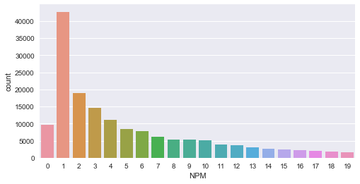

```python
sns.countplot(data = classes_df[classes_df["NPM"] < 20], x = "NPM");
```

#### 9.15) NS

*Number of setters*, número de métodos set de la clase.

```python
classes_df["NS"].describe()
```

```
count    182671.000000
mean          0.853212
std           3.002555
min           0.000000
25%           0.000000
50%           0.000000
75%           0.000000
max          97.000000
Name: NS, dtype: float64
```

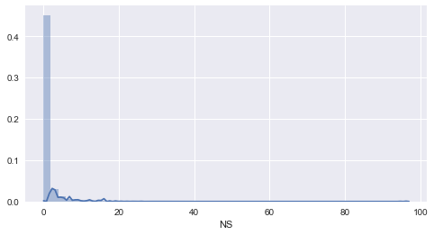

```python
sns.distplot(classes_df["NS"]);
```

Casi todas las clases no tienen funciones set.

#### 9.17) TLLOC y TLOC

*Total logical lines of code* y *Total lines of code*, número de líneas de código. Se diferencian coon LLOC y LOC en que también incluye clases anidadas anónimas y clases locales.

```python
classes_df["LLOC"].corr(classes_df["TLLOC"])
```

```
0.953460788331944
```

```python
classes_df["LOC"].corr(classes_df["TLOC"])
```

```
0.9602585973838352
```

Debido a que expresan casi lo mismo que LLOC y LOC (se puede ver como están fuertemente correlacionadas con su par), podemos eliminarlas ya que no nos dan muchas más información.

```python
classes_df = classes_df.drop(["TLLOC", "TLOC"], 1)
```

#### 9.18) NLA

*Number of local attributes*, número de atributos locales de la clase.

```python
classes_df["NLA"].describe()
```

```
count    182671.000000
mean          2.074336
std           4.430673
min           0.000000
25%           0.000000
50%           1.000000
75%           3.000000
max         213.000000
Name: NLA, dtype: float64
```

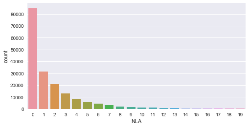

```python
sns.countplot(data = classes_df[classes_df["NLA"] < 20], x = "NLA");
```

El número de valores a 0 es bastante inferior que en el caso de NLPA (atributos públicos).

#### 9.19) TNG

*Total number getters*, número de funciones get en la clase.

```python
classes_df["TNG"].describe()
```

```
count    182671.000000
mean          2.402456
std           8.182219
min           0.000000
25%           0.000000
50%           0.000000
75%           2.000000
max        1099.000000
Name: TNG, dtype: float64
```

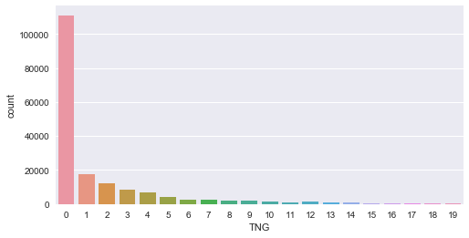

```python
sns.countplot(data = classes_df[classes_df["TNG"] < 20], x = "TNG");
```

```python
atts = ""
for att in classes_df.columns[29:53]:
    atts = atts + '", "' + att
print("Lista completa de características")
atts[2:]
```

```
Lista completa de características
```

```
' "LLOC", "LOC", "NA", "NG", "NLA", "NLG", "NLM", "NLPA", "NLPM", "NLS", "NM", "NOS", "NPA", "NPM", "NS", "TNA", "TNG", "TNLA", "TNLG", "TNLM", "TNLPA", "TNLPM", "TNLS", "TNM'
```

#### 9.20) TNLA

*Total number of local attributes*, número de atributos locales en la clase, incluyendo atributos de clases anidadas, anónimas y locales.

```python
classes_df["TNLA"].corr(classes_df["NLA"])
```

```
0.8574851107916474
```

```python
classes_df["TNLA"].describe()
```

```
count    182671.000000
mean          2.545073
std           5.915054
min           0.000000
25%           0.000000
50%           1.000000
75%           3.000000
max         238.000000
Name: TNLA, dtype: float64
```

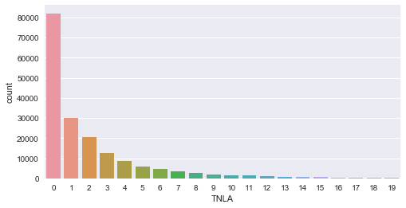

```python
sns.countplot(data = classes_df[classes_df["TNLA"] < 20], x = "TNLA");
```

#### 9.20) TNLG

*Total number of local getters*, número de funciones get en la clase, incluyendo getters de clases anidadas, anónimas y locales.

```python
classes_df["TNLG"].corr(classes_df["NLG"])
```

```
0.9190317027893011
```

```python
classes_df["TNLG"].describe()
```

```
count    182671.000000
mean          1.027777
std           3.345582
min           0.000000
25%           0.000000
50%           0.000000
75%           1.000000
max         224.000000
Name: TNLG, dtype: float64
```

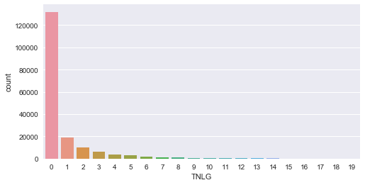

```python
sns.countplot(data = classes_df[classes_df["TNLG"] < 20], x = "TNLG");
```

#### 9.21) TNLM

*Total number of local methods*, número de métodos locales en la clase, incluyendo métodos de clases anidadas, anónimas y locales.

```python
classes_df["TNLM"].corr(classes_df["NLM"])
```

```
0.8755574511108437
```

```python
classes_df["TNLM"].describe()
```

```
count    182671.000000
mean          6.928139
std          12.640786
min           0.000000
25%           1.000000
50%           3.000000
75%           8.000000
max         715.000000
Name: TNLM, dtype: float64
```

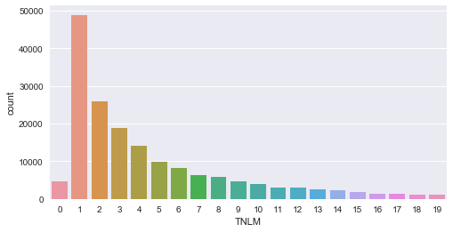

```python
sns.countplot(data = classes_df[classes_df["TNLM"] < 20], x = "TNLM");
```

#### 9.22) TNLPA

*Total number of local public attributes*, número de atributos públicos locales en la clase, incluyendo atributos de clases anidadas, anónimas y locales.

```python
classes_df["TNLPA"].corr(classes_df["NLPA"])
```

```
0.8251948508653979
```

```python
classes_df["TNLPA"].describe()
```

```
count    182671.000000
mean          0.429515
std           3.170616
min           0.000000
25%           0.000000
50%           0.000000
75%           0.000000
max         235.000000
Name: TNLPA, dtype: float64
```

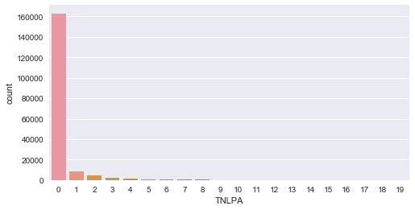

```python
sns.countplot(data = classes_df[classes_df["TNLPA"] < 20], x = "TNLPA");
```

#### 9.23) TNLPM

*Total number of local public methods*, número de métodos públicos locales en la clase, incluyendo métodos de clases anidadas, anónimas y locales. Esta característica es casi idéntica a TNLM (Número de métodos locales), por lo que se puede eliminar.

```python
classes_df["TNLPM"].corr(classes_df["TNLM"])
```

```
0.9570841799287519
```

```python
classes_df = classes_df.drop("TNLPM", 1)
```

#### 9.24) TNLS

*Total number of local setters*, número de funciones set locales en la clase, incluyendo funciones de clases anidadas, anónimas y locales. Esta característica es casi idéntica a NLS (Número de setters locales), así que se puede eliminar.

```python
classes_df["TNLS"].corr(classes_df["NLS"])
```

```
0.979777496933896
```

```python
classes_df = classes_df.drop("TNLS", 1)
```

#### 9.25) TNM

*Total number of methods*, número de métodos de la clase, incluyendo heredados.

```python
classes_df["TNM"].describe()
```

```
count    182671.000000
mean         16.010407
std          41.203958
min           0.000000
25%           2.000000
50%           6.000000
75%          17.000000
max        4602.000000
Name: TNM, dtype: float64
```

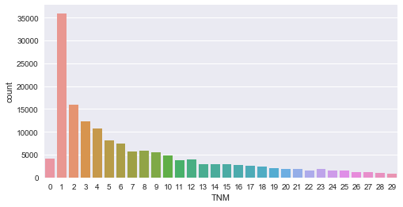

```python
sns.countplot(data = classes_df[classes_df["TNM"] < 30], x = "TNM");
```

#### 9.26) TNOS

*Total number of statements*, número de declaraciones en la clase. Al ser casi idéntica a NOS (Número de declaraciones), se puede eliminar.

```python
classes_df["NOS"].corr(classes_df["TNOS"])
```

```
0.9752421352975511
```

```python
classes_df = classes_df.drop("TNOS", 1)
```

#### 9.27) TNPA

*Number of public attributes*, número de atributos públicos en la clase, incluyendo heredados.

```python
classes_df["NPA"].corr(classes_df["TNPA"])
```

```
0.9169834455548495
```

```python
classes_df["TNPA"].describe()
```

```
count    182671.000000
mean          1.376349
std           5.411447
min           0.000000
25%           0.000000
50%           0.000000
75%           0.000000
max         265.000000
Name: TNPA, dtype: float64
```

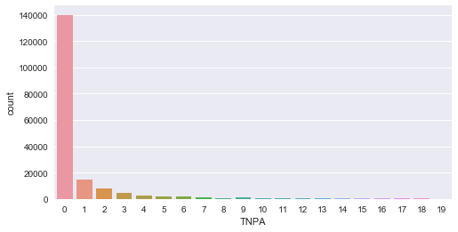

```python
sns.countplot(data = classes_df[classes_df["TNPA"] < 20], x = "TNPA");
```

#### 9.28) TNPM

*Total number of public methods*. Al ser casi idéntica a TNM (Número de métodos totales), se puede eliminar.

```python
classes_df["TNPM"].corr(classes_df["TNM"])
```

```
0.9742937461125778
```

```python
classes_df = classes_df.drop("TNPM", 1)
```

#### 9.29) TNS

*Total number of setters*, incluyendo heredados.

```python
classes_df["TNS"].corr(classes_df["NS"])
```

```
0.7895323826818113
```

```python
classes_df["TNS"].describe()
```

```
count    182671.000000
mean          0.958351
std           3.806823
min           0.000000
25%           0.000000
50%           0.000000
75%           0.000000
max         409.000000
Name: TNS, dtype: float64
```

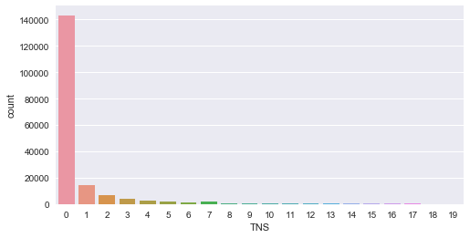

```python
sns.countplot(data = classes_df[classes_df["TNS"] < 20], x = "TNS");
```

#### Resumen métricas de tamaño

```python
prueba = classes_df[["LLOC", "LOC", "NA", "NLG", "NLM", "NLPA", "NLPM", "NM", "NOS", "NPA", "NPM", "NS", "TNA", "TNLA", "TNLG", "TNLM", "TNLPA", "TNM", "TNPA", "TNS"]].corr()
prueba[prueba > 0.9]
```

|  | LLOC | LOC | NA | NLG | NLM | NLPA | NLPM | NM | NOS | NPA | NPM | NS | TNA | TNLA | TNLG | TNLM | TNLPA | TNM | TNPA | TNS |
| --- | --- | --- | --- | --- | --- | --- | --- | --- | --- | --- | --- | --- | --- | --- | --- | --- | --- | --- | --- | --- |
| LLOC | 1.000000 | 0.984208 | NaN | NaN | NaN | NaN | NaN | NaN | 0.967288 | NaN | NaN | NaN | NaN | NaN | NaN | NaN | NaN | NaN | NaN | NaN |
| LOC | 0.984208 | 1.000000 | NaN | NaN | NaN | NaN | NaN | NaN | 0.941284 | NaN | NaN | NaN | NaN | NaN | NaN | NaN | NaN | NaN | NaN | NaN |
| NA | NaN | NaN | 1.000000 | NaN | NaN | NaN | NaN | NaN | NaN | NaN | NaN | NaN | 0.904334 | NaN | NaN | NaN | NaN | NaN | NaN | NaN |
| NLG | NaN | NaN | NaN | 1.000000 | NaN | NaN | NaN | NaN | NaN | NaN | NaN | NaN | NaN | NaN | 0.919032 | NaN | NaN | NaN | NaN | NaN |
| NLM | NaN | NaN | NaN | NaN | 1.000000 | NaN | 0.947573 | NaN | NaN | NaN | NaN | NaN | NaN | NaN | NaN | NaN | NaN | NaN | NaN | NaN |
| NLPA | NaN | NaN | NaN | NaN | NaN | 1.0 | NaN | NaN | NaN | NaN | NaN | NaN | NaN | NaN | NaN | NaN | NaN | NaN | NaN | NaN |
| NLPM | NaN | NaN | NaN | NaN | 0.947573 | NaN | 1.000000 | NaN | NaN | NaN | NaN | NaN | NaN | NaN | NaN | NaN | NaN | NaN | NaN | NaN |
| NM | NaN | NaN | NaN | NaN | NaN | NaN | NaN | 1.00000 | NaN | NaN | 0.95678 | NaN | NaN | NaN | NaN | NaN | NaN | NaN | NaN | NaN |
| NOS | 0.967288 | 0.941284 | NaN | NaN | NaN | NaN | NaN | NaN | 1.000000 | NaN | NaN | NaN | NaN | NaN | NaN | NaN | NaN | NaN | NaN | NaN |
| NPA | NaN | NaN | NaN | NaN | NaN | NaN | NaN | NaN | NaN | 1.000000 | NaN | NaN | NaN | NaN | NaN | NaN | NaN | NaN | 0.916983 | NaN |
| NPM | NaN | NaN | NaN | NaN | NaN | NaN | NaN | 0.95678 | NaN | NaN | 1.00000 | NaN | NaN | NaN | NaN | NaN | NaN | NaN | NaN | NaN |
| NS | NaN | NaN | NaN | NaN | NaN | NaN | NaN | NaN | NaN | NaN | NaN | 1.0 | NaN | NaN | NaN | NaN | NaN | NaN | NaN | NaN |
| TNA | NaN | NaN | 0.904334 | NaN | NaN | NaN | NaN | NaN | NaN | NaN | NaN | NaN | 1.000000 | NaN | NaN | NaN | NaN | NaN | NaN | NaN |
| TNLA | NaN | NaN | NaN | NaN | NaN | NaN | NaN | NaN | NaN | NaN | NaN | NaN | NaN | 1.0 | NaN | NaN | NaN | NaN | NaN | NaN |
| TNLG | NaN | NaN | NaN | 0.919032 | NaN | NaN | NaN | NaN | NaN | NaN | NaN | NaN | NaN | NaN | 1.000000 | NaN | NaN | NaN | NaN | NaN |
| TNLM | NaN | NaN | NaN | NaN | NaN | NaN | NaN | NaN | NaN | NaN | NaN | NaN | NaN | NaN | NaN | 1.0 | NaN | NaN | NaN | NaN |
| TNLPA | NaN | NaN | NaN | NaN | NaN | NaN | NaN | NaN | NaN | NaN | NaN | NaN | NaN | NaN | NaN | NaN | 1.0 | NaN | NaN | NaN |
| TNM | NaN | NaN | NaN | NaN | NaN | NaN | NaN | NaN | NaN | NaN | NaN | NaN | NaN | NaN | NaN | NaN | NaN | 1.0 | NaN | NaN |
| TNPA | NaN | NaN | NaN | NaN | NaN | NaN | NaN | NaN | NaN | 0.916983 | NaN | NaN | NaN | NaN | NaN | NaN | NaN | NaN | 1.000000 | NaN |
| TNS | NaN | NaN | NaN | NaN | NaN | NaN | NaN | NaN | NaN | NaN | NaN | NaN | NaN | NaN | NaN | NaN | NaN | NaN | NaN | 1.0 |

Vemos como entre LLOC y LOC hay una correlación muy fuerte (más del 98%), entre NLPM y NLM hay una correlación de casi el 95%, y entre NM y NPM hay una correlación de más del 95% por lo que eliminaremos una variable de cada par.

```python
classes_df = classes_df.drop(["LLOC", "NLPM", "NPM"], 1)
```

### 10) Warnings

#### 10.1) WarningBlocker

```python
classes_df["WarningBlocker"].describe()
```

```
count    182671.000000
mean          0.000066
std           0.008105
min           0.000000
25%           0.000000
50%           0.000000
75%           0.000000
max           1.000000
Name: WarningBlocker, dtype: float64
```

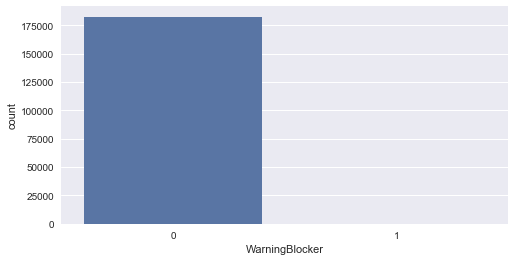

```python
sns.countplot(data = classes_df, x = "WarningBlocker");
```

```python
len(classes_df[classes_df["WarningBlocker"] == 1])
```

```
12
```

Debido a que solo hay 12 casos de los 182671 casos con este valor a 1 lo podemos eliminar.

```python
classes_df = classes_df.drop("WarningBlocker", 1)
```

#### 10.2) WarningCritical

```python
classes_df["WarningCritical"].describe()
```

```
count    182671.000000
mean          0.209924
std           1.622087
min           0.000000
25%           0.000000
50%           0.000000
75%           0.000000
max          92.000000
Name: WarningCritical, dtype: float64
```

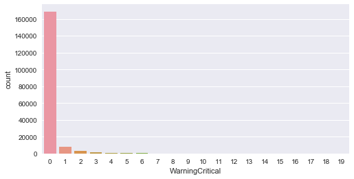

```python
sns.countplot(data = classes_df[classes_df["WarningCritical"] < 20], x = "WarningCritical");
```

```python
len(classes_df[classes_df["WarningCritical"] > 0])
```

```
13785
```

#### 10.3) WarningInfo

```python
classes_df["WarningInfo"].describe()
```

```
count    182671.000000
mean         25.498875
std          47.716915
min           0.000000
25%           7.000000
50%          13.000000
75%          26.000000
max        2889.000000
Name: WarningInfo, dtype: float64
```

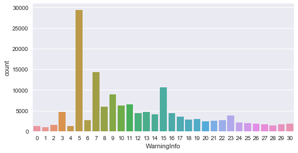

```python
sns.countplot(data = classes_df[classes_df["WarningInfo"] <= 30], x = "WarningInfo");
```

#### 10.4) WarningMajor

```python
classes_df["WarningMajor"].describe()
```

```
count    182671.000000
mean          1.439128
std           5.810139
min           0.000000
25%           0.000000
50%           0.000000
75%           1.000000
max         778.000000
Name: WarningMajor, dtype: float64
```

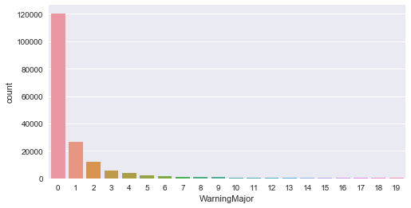

```python
sns.countplot(data = classes_df[classes_df["WarningMajor"] < 20], x = "WarningMajor");
```

```python
len(classes_df[classes_df["WarningMajor"] > 0])
```

```
62252
```

#### 10.5) WarningMinor

```python
classes_df["WarningMinor"].describe()
```

```
count    182671.000000
mean          6.106810
std          38.177391
min           0.000000
25%           0.000000
50%           1.000000
75%           5.000000
max        4541.000000
Name: WarningMinor, dtype: float64
```

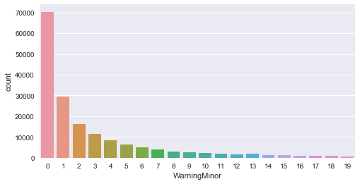

```python
sns.countplot(data = classes_df[classes_df["WarningMinor"] < 20], x = "WarningMinor");
```

```python
len(classes_df[classes_df["WarningMinor"] > 0])
```

```
112334
```

### 11) Rules violation

```python
def lookRuleAtt(att):
    # Descrbie de la variable
    print(classes_df[att].describe())
    # Numero de casos distintos de 0
    l = len(classes_df[classes_df[att] > 0])
    ratio = l / len(classes_df)
    print("Casos distintos de 0: ", l)
    # Si representan mas del 5%, imprimir distribucion de los primeros valores
    if (ratio >= 0.05):
        sns.countplot(data = classes_df[classes_df[att] < 20], x = att);
```

#### 11.1) Android Rules

```python
lookRuleAtt("Android Rules")
```

```
count    182671.000000
mean          0.000153
std           0.017818
min           0.000000
25%           0.000000
50%           0.000000
75%           0.000000
max           3.000000
Name: Android Rules, dtype: float64
Casos distintos de 0:  16
```

Debido a que solo hay 16 valores distintos de 0 en nuestro conjunto de entrenamiento se puede eliminar este atributo.

```python
classes_df = classes_df.drop("Android Rules", 1)
```

#### 11.2) Basic Rules

Violación de conjunto de reglas básicas.

```
count    182671.000000
mean          0.154261
std           6.066099
min           0.000000
25%           0.000000
50%           0.000000
75%           0.000000
max         925.000000
Name: Basic Rules, dtype: float64
Casos distintos de 0:  9583
```

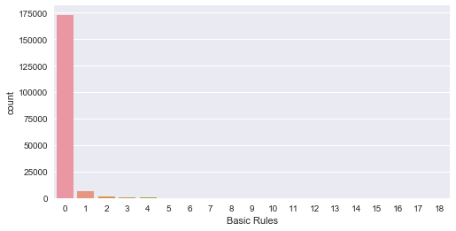

```python
lookRuleAtt("Basic Rules")
```

#### 11.3) Brace Rules

Violación de reglas relacionadas con el uso y colocación de llaves.

```
count    182671.000000
mean          1.228641
std          10.216323
min           0.000000
25%           0.000000
50%           0.000000
75%           0.000000
max        2324.000000
Name: Brace Rules, dtype: float64
Casos distintos de 0:  21165
```

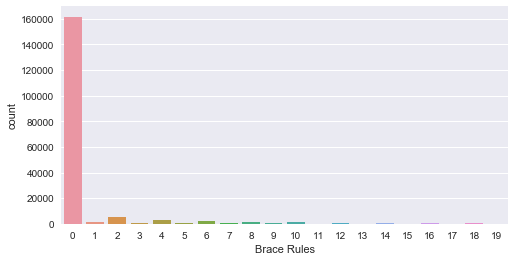

```python
lookRuleAtt("Brace Rules")
```

#### 11.4) Clone Implementation Rules

```python
lookRuleAtt("Clone Implementation Rules")
```

```
count    182671.000000
mean          0.004379
std           0.079843
min           0.000000
25%           0.000000
50%           0.000000
75%           0.000000
max           5.000000
Name: Clone Implementation Rules, dtype: float64
Casos distintos de 0:  634
```

Al haber muy pocos valores distintos de 0 se puede eliminar.

```python
classes_df = classes_df.drop("Clone Implementation Rules", 1)
```

#### 11.5) Clone Metric Rules

```
count    182671.000000
mean          6.097366
std          21.963008
min           0.000000
25%           0.000000
50%           0.000000
75%           0.000000
max        1053.000000
Name: Clone Metric Rules, dtype: float64
Casos distintos de 0:  45457
```

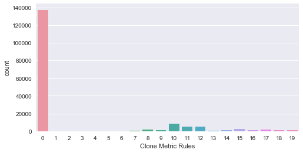

```python
lookRuleAtt("Clone Metric Rules")
```

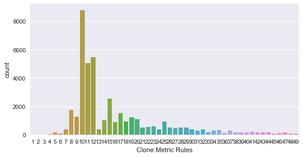

```python
sns.countplot(data = classes_df[(classes_df["Clone Metric Rules"] > 0) & (classes_df["Clone Metric Rules"] < 50)], x = "Clone Metric Rules");
```

#### 11.6) Code Size Rules

```python
lookRuleAtt("Code Size Rules")
```

```
count    182671.0
mean          0.0
std           0.0
min           0.0
25%           0.0
50%           0.0
75%           0.0
max           0.0
Name: Code Size Rules, dtype: float64
Casos distintos de 0:  0
```

Todos los valores son 0, se puede eliminar.

```python
classes_df = classes_df.drop("Code Size Rules", 1)
```